# StarbucksWorkspace

Starbucks Capstone Challenge Introduction

This data set contains simulated data that mimics customer behavior on the Starbucks rewards mobile app. Once every few days, Starbucks sends out an offer to users of the mobile app. An offer can be merely an advertisement for a drink or an actual offer such as a discount or BOGO (buy one get one free). Some users might not receive any offer during certain weeks.

Not all users receive the same offer, and that is the challenge to solve with this data set.

Your task is to combine transaction, demographic and offer data to determine which demographic groups respond best to which offer type. This data set is a simplified version of the real Starbucks app because the underlying simulator only has one product whereas Starbucks actually sells dozens of products.

Every offer has a validity period before the offer expires. As an example, a BOGO offer might be valid for only 5 days. You'll see in the data set that informational offers have a validity period even though these ads are merely providing information about a product; for example, if an informational offer has 7 days of validity, you can assume the customer is feeling the influence of the offer for 7 days after receiving the advertisement.

You'll be given transactional data showing user purchases made on the app including the timestamp of purchase and the amount of money spent on a purchase. This transactional data also has a record for each offer that a user receives as well as a record for when a user actually views the offer. There are also records for when a user completes an offer.

Keep in mind as well that someone using the app might make a purchase through the app without having received an offer or seen an offer. Example

To give an example, a user could receive a discount offer buy 10 dollars get 2 off on Monday. The offer is valid for 10 days from receipt. If the customer accumulates at least 10 dollars in purchases during the validity period, the customer completes the offer.

However, there are a few things to watch out for in this data set. Customers do not opt into the offers that they receive; in other words, a user can receive an offer, never actually view the offer, and still complete the offer. For example, a user might receive the "buy 10 dollars get 2 dollars off offer", but the user never opens the offer during the 10 day validity period. The customer spends 15 dollars during those ten days. There will be an offer completion record in the data set; however, the customer was not influenced by the offer because the customer never viewed the offer. Cleaning

This makes data cleaning especially important and tricky.

You'll also want to take into account that some demographic groups will make purchases even if they don't receive an offer. From a business perspective, if a customer is going to make a 10 dollar purchase without an offer anyway, you wouldn't want to send a buy 10 dollars get 2 dollars off offer. You'll want to try to assess what a certain demographic group will buy when not receiving any offers. Final Advice

Because this is a capstone project, you are free to analyze the data any way you see fit. For example, you could build a machine learning model that predicts how much someone will spend based on demographics and offer type. Or you could build a model that predicts whether or not someone will respond to an offer. Or, you don't need to build a machine learning model at all. You could develop a set of heuristics that determine what offer you should send to each customer (i.e., 75 percent of women customers who were 35 years old responded to offer A vs 40 percent from the same demographic to offer B, so send offer A).

## Data Sets

The data is contained in three files:

```
portfolio.json - containing offer ids and meta data about each offer (duration, type, etc.)
profile.json - demographic data for each customer
transcript.json - records for transactions, offers received, offers viewed, and offers completed
```

Here is the schema and explanation of each variable in the files:

portfolio.json

```
id (string) - offer id
offer_type (string) - type of offer ie BOGO, discount, informational
difficulty (int) - minimum required spend to complete an offer
reward (int) - reward given for completing an offer
duration (int) - time for offer to be open, in days
channels (list of strings)
```

profile.json

```
age (int) - age of the customer
became_member_on (int) - date when customer created an app account
gender (str) - gender of the customer (note some entries contain 'O' for other rather than M or F)
id (str) - customer id
income (float) - customer's income
```

transcript.json

```
event (str) - record description (ie transaction, offer received, offer viewed, etc.)
person (str) - customer id
time (int) - time in hours since start of test. The data begins at time t=0
value - (dict of strings) - either an offer id or transaction amount depending on the record
```

```python
import pandas as pd
import numpy as np
import math
import json
%matplotlib inline
from datetime import datetime

# read in the json files
portfolio = pd.read_json('data/portfolio.json', orient='records', lines=True)
profile = pd.read_json('data/profile.json', orient='records', lines=True)
transcript = pd.read_json('data/transcript.json', orient='records', lines=True)
```

```python
portfolio.head()
```

|  | reward | channels | difficulty | duration | offer_type | id |
| --- | --- | --- | --- | --- | --- | --- |
| 0 | 10 | [email, mobile, social] | 10 | 7 | bogo | ae264e3637204a6fb9bb56bc8210ddfd |
| 1 | 10 | [web, email, mobile, social] | 10 | 5 | bogo | 4d5c57ea9a6940dd891ad53e9dbe8da0 |
| 2 | 0 | [web, email, mobile] | 0 | 4 | informational | 3f207df678b143eea3cee63160fa8bed |
| 3 | 5 | [web, email, mobile] | 5 | 7 | bogo | 9b98b8c7a33c4b65b9aebfe6a799e6d9 |
| 4 | 5 | [web, email] | 20 | 10 | discount | 0b1e1539f2cc45b7b9fa7c272da2e1d7 |

```python
profile.head(10)
```

|  | gender | age | id | became_member_on | income |
| --- | --- | --- | --- | --- | --- |
| 0 | None | 118 | 68be06ca386d4c31939f3a4f0e3dd783 | 20170212 | NaN |
| 1 | F | 55 | 0610b486422d4921ae7d2bf64640c50b | 20170715 | 112000.0 |
| 2 | None | 118 | 38fe809add3b4fcf9315a9694bb96ff5 | 20180712 | NaN |
| 3 | F | 75 | 78afa995795e4d85b5d9ceeca43f5fef | 20170509 | 100000.0 |
| 4 | None | 118 | a03223e636434f42ac4c3df47e8bac43 | 20170804 | NaN |
| 5 | M | 68 | e2127556f4f64592b11af22de27a7932 | 20180426 | 70000.0 |
| 6 | None | 118 | 8ec6ce2a7e7949b1bf142def7d0e0586 | 20170925 | NaN |
| 7 | None | 118 | 68617ca6246f4fbc85e91a2a49552598 | 20171002 | NaN |
| 8 | M | 65 | 389bc3fa690240e798340f5a15918d5c | 20180209 | 53000.0 |
| 9 | None | 118 | 8974fc5686fe429db53ddde067b88302 | 20161122 | NaN |

```python
transcript.head(15)
```

|  | person | event | value | time |
| --- | --- | --- | --- | --- |
| 0 | 78afa995795e4d85b5d9ceeca43f5fef | offer received | {'offer id': '9b98b8c7a33c4b65b9aebfe6a799e6d9'} | 0 |
| 1 | a03223e636434f42ac4c3df47e8bac43 | offer received | {'offer id': '0b1e1539f2cc45b7b9fa7c272da2e1d7'} | 0 |
| 2 | e2127556f4f64592b11af22de27a7932 | offer received | {'offer id': '2906b810c7d4411798c6938adc9daaa5'} | 0 |
| 3 | 8ec6ce2a7e7949b1bf142def7d0e0586 | offer received | {'offer id': 'fafdcd668e3743c1bb461111dcafc2a4'} | 0 |
| 4 | 68617ca6246f4fbc85e91a2a49552598 | offer received | {'offer id': '4d5c57ea9a6940dd891ad53e9dbe8da0'} | 0 |
| 5 | 389bc3fa690240e798340f5a15918d5c | offer received | {'offer id': 'f19421c1d4aa40978ebb69ca19b0e20d'} | 0 |
| 6 | c4863c7985cf408faee930f111475da3 | offer received | {'offer id': '2298d6c36e964ae4a3e7e9706d1fb8c2'} | 0 |
| 7 | 2eeac8d8feae4a8cad5a6af0499a211d | offer received | {'offer id': '3f207df678b143eea3cee63160fa8bed'} | 0 |
| 8 | aa4862eba776480b8bb9c68455b8c2e1 | offer received | {'offer id': '0b1e1539f2cc45b7b9fa7c272da2e1d7'} | 0 |
| 9 | 31dda685af34476cad5bc968bdb01c53 | offer received | {'offer id': '0b1e1539f2cc45b7b9fa7c272da2e1d7'} | 0 |
| 10 | 744d603ef08c4f33af5a61c8c7628d1c | offer received | {'offer id': '0b1e1539f2cc45b7b9fa7c272da2e1d7'} | 0 |
| 11 | 3d02345581554e81b7b289ab5e288078 | offer received | {'offer id': '0b1e1539f2cc45b7b9fa7c272da2e1d7'} | 0 |
| 12 | 4b0da7e80e5945209a1fdddfe813dbe0 | offer received | {'offer id': 'ae264e3637204a6fb9bb56bc8210ddfd'} | 0 |
| 13 | c27e0d6ab72c455a8bb66d980963de60 | offer received | {'offer id': '3f207df678b143eea3cee63160fa8bed'} | 0 |
| 14 | d53717f5400c4e84affdaeda9dd926b3 | offer received | {'offer id': '0b1e1539f2cc45b7b9fa7c272da2e1d7'} | 0 |

```python
profile.head()
```

|  | gender | age | id | became_member_on | income |
| --- | --- | --- | --- | --- | --- |
| 0 | None | 118 | 68be06ca386d4c31939f3a4f0e3dd783 | 20170212 | NaN |
| 1 | F | 55 | 0610b486422d4921ae7d2bf64640c50b | 20170715 | 112000.0 |
| 2 | None | 118 | 38fe809add3b4fcf9315a9694bb96ff5 | 20180712 | NaN |
| 3 | F | 75 | 78afa995795e4d85b5d9ceeca43f5fef | 20170509 | 100000.0 |
| 4 | None | 118 | a03223e636434f42ac4c3df47e8bac43 | 20170804 | NaN |

```python
profile["gender"].value_counts()
```

```
gender
M    8484
F    6129
O     212
Name: count, dtype: int64
```

### Data Exploration

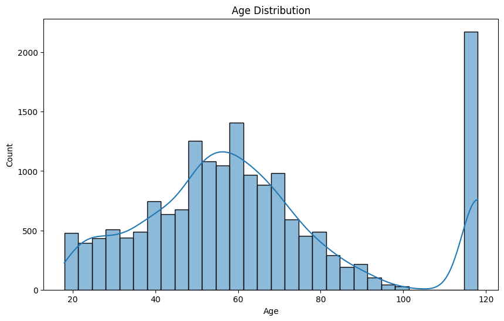

```python
import matplotlib.pyplot as plt
import seaborn as sns

plt.figure(figsize=(10, 6))
sns.histplot(profile['age'], bins=30, kde=True)
plt.title('Age Distribution')
plt.xlabel('Age')
plt.ylabel('Count')
plt.show()
```

We can see that we have a large number of outliers in the 118 area

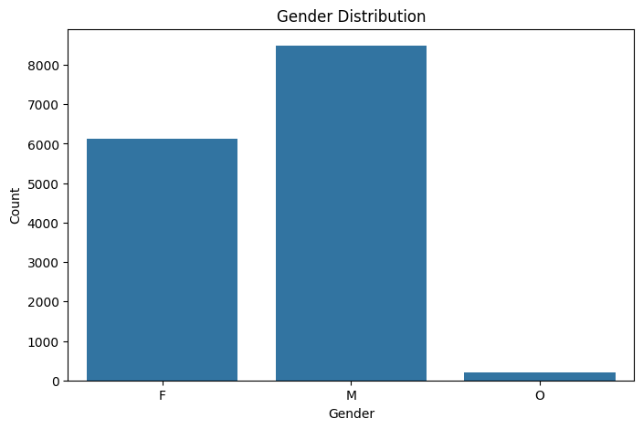

```python
plt.figure(figsize=(8, 5))
sns.countplot(x='gender', data=profile)
plt.title('Gender Distribution')
plt.xlabel('Gender')
plt.ylabel('Count')
plt.show()
```

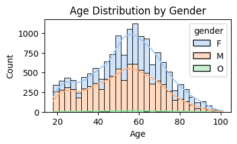

```python
# Set the figure size
plt.figure(figsize=(4,2))

# Create an overlapped histogram
sns.histplot(data=profile, x='age', hue='gender', multiple="stack", bins=30, kde=True, palette='pastel')

# Add labels and title
plt.title('Age Distribution by Gender')
plt.xlabel('Age')
plt.ylabel('Count')

# Show the plot
plt.show()
```

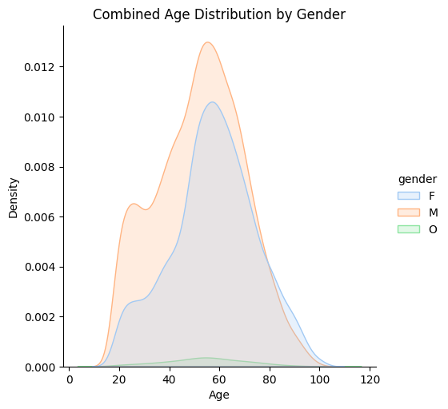

```python
plt.figure(figsize=(4,2))

# Create a combined distribution plot
sns.displot(profile, x="age", hue="gender", kind="kde", fill=True, palette="pastel")

# Add labels and title
plt.title('Combined Age Distribution by Gender')
plt.xlabel('Age')
plt.ylabel('Density')

# Show the plot
plt.show()
```

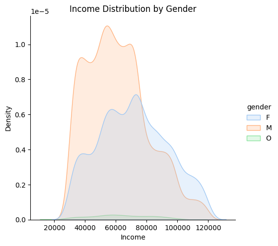

```python
# Set the figure size
plt.figure(figsize=(12, 8))

# Create a combined distribution plot for income by gender
sns.displot(profile, x="income", hue="gender", kind="kde", fill=True, palette="pastel")

# Add labels and title
plt.title('Income Distribution by Gender')
plt.xlabel('Income')
plt.ylabel('Density')

# Show the plot
plt.show()
```

### Data Processing

```python
def clean_profile(profile):

    '''
    Function to clean profile dataframe.

    INPUT - Profile dataframe

    OUTPUT - Return cleaned version of profile dataframe

    '''

    #Convert became_member_on to datetime
    profile['became_member_on'] = pd.to_datetime(profile['became_member_on'],format='%Y%m%d')


    #Convert users with age 118 to np.nan
    profile['age'] = profile['age'].apply(lambda x: np.nan if x ==118 else x)

    #Create dummy columns for gender

    genders = pd.get_dummies(profile['gender'],prefix = "gender", prefix_sep = "-")

    profile = pd.concat([profile,genders],axis=1)

    #Change id column name to offer id

    profile.rename(columns={'id':'customer_id'},inplace=True)

    #Extract the number of days a user has been a member of the rewards app.
    today = pd.to_datetime(datetime.today().strftime('%Y%m%d'))


    profile['number_of_days'] = (today - profile['became_member_on']) / np.timedelta64(1,'D')



    return profile



profile = clean_profile(profile)
profile.head()
```

|  | gender | age | customer_id | became_member_on | income | gender-F | gender-M | gender-O | number_of_days |
| --- | --- | --- | --- | --- | --- | --- | --- | --- | --- |
| 0 | None | NaN | 68be06ca386d4c31939f3a4f0e3dd783 | 2017-02-12 | NaN | False | False | False | 2491.0 |
| 1 | F | 55.0 | 0610b486422d4921ae7d2bf64640c50b | 2017-07-15 | 112000.0 | True | False | False | 2338.0 |
| 2 | None | NaN | 38fe809add3b4fcf9315a9694bb96ff5 | 2018-07-12 | NaN | False | False | False | 1976.0 |
| 3 | F | 75.0 | 78afa995795e4d85b5d9ceeca43f5fef | 2017-05-09 | 100000.0 | True | False | False | 2405.0 |
| 4 | None | NaN | a03223e636434f42ac4c3df47e8bac43 | 2017-08-04 | NaN | False | False | False | 2318.0 |

```python
profile.head(15)
```

|  | gender | age | customer_id | became_member_on | income | gender-F | gender-M | gender-O | number_of_days |
| --- | --- | --- | --- | --- | --- | --- | --- | --- | --- |
| 0 | None | NaN | 68be06ca386d4c31939f3a4f0e3dd783 | 2017-02-12 | NaN | False | False | False | 2491.0 |
| 1 | F | 55.0 | 0610b486422d4921ae7d2bf64640c50b | 2017-07-15 | 112000.0 | True | False | False | 2338.0 |
| 2 | None | NaN | 38fe809add3b4fcf9315a9694bb96ff5 | 2018-07-12 | NaN | False | False | False | 1976.0 |
| 3 | F | 75.0 | 78afa995795e4d85b5d9ceeca43f5fef | 2017-05-09 | 100000.0 | True | False | False | 2405.0 |
| 4 | None | NaN | a03223e636434f42ac4c3df47e8bac43 | 2017-08-04 | NaN | False | False | False | 2318.0 |
| 5 | M | 68.0 | e2127556f4f64592b11af22de27a7932 | 2018-04-26 | 70000.0 | False | True | False | 2053.0 |
| 6 | None | NaN | 8ec6ce2a7e7949b1bf142def7d0e0586 | 2017-09-25 | NaN | False | False | False | 2266.0 |
| 7 | None | NaN | 68617ca6246f4fbc85e91a2a49552598 | 2017-10-02 | NaN | False | False | False | 2259.0 |
| 8 | M | 65.0 | 389bc3fa690240e798340f5a15918d5c | 2018-02-09 | 53000.0 | False | True | False | 2129.0 |
| 9 | None | NaN | 8974fc5686fe429db53ddde067b88302 | 2016-11-22 | NaN | False | False | False | 2573.0 |
| 10 | None | NaN | c4863c7985cf408faee930f111475da3 | 2017-08-24 | NaN | False | False | False | 2298.0 |
| 11 | None | NaN | 148adfcaa27d485b82f323aaaad036bd | 2015-09-19 | NaN | False | False | False | 3003.0 |
| 12 | M | 58.0 | 2eeac8d8feae4a8cad5a6af0499a211d | 2017-11-11 | 51000.0 | False | True | False | 2219.0 |
| 13 | F | 61.0 | aa4862eba776480b8bb9c68455b8c2e1 | 2017-09-11 | 57000.0 | True | False | False | 2280.0 |
| 14 | M | 26.0 | e12aeaf2d47d42479ea1c4ac3d8286c6 | 2014-02-13 | 46000.0 | False | True | False | 3586.0 |

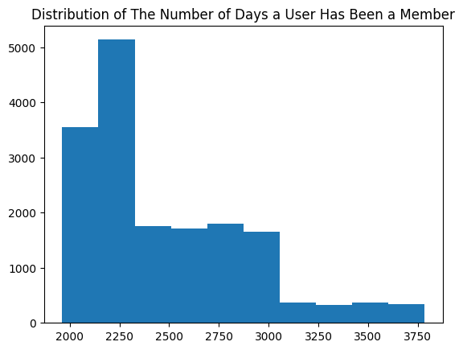

```python
plt.hist(profile['number_of_days']);
plt.title('Distribution of The Number of Days a User Has Been a Member');
```

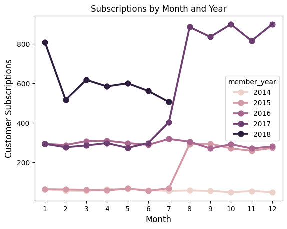

```python
# Extract year and month from the 'became_member_on' column
profile['member_year'] = profile['became_member_on'].dt.year
profile['member_month'] = profile['became_member_on'].dt.month

# Filter data for years >= 2014 and group by year and month, counting the number of IDs
membership_subs = profile[profile['member_year'] >= 2014].groupby(['member_year', 'member_month'], as_index=False)['customer_id'].count()

# Plotting
sns.pointplot(x='member_month', y='customer_id', hue='member_year', data=membership_subs)
plt.ylabel('Customer Subscriptions', fontsize=12)
plt.xlabel('Month', fontsize=12)
plt.title('Subscriptions by Month and Year')
plt.show()
```

#### Exploring the portfolio dataframe and cleaning it up

```python
#Explore portfolio
portfolio.head()
```

|  | reward | channels | difficulty | duration | offer_type | id |
| --- | --- | --- | --- | --- | --- | --- |
| 0 | 10 | [email, mobile, social] | 10 | 7 | bogo | ae264e3637204a6fb9bb56bc8210ddfd |
| 1 | 10 | [web, email, mobile, social] | 10 | 5 | bogo | 4d5c57ea9a6940dd891ad53e9dbe8da0 |
| 2 | 0 | [web, email, mobile] | 0 | 4 | informational | 3f207df678b143eea3cee63160fa8bed |
| 3 | 5 | [web, email, mobile] | 5 | 7 | bogo | 9b98b8c7a33c4b65b9aebfe6a799e6d9 |
| 4 | 5 | [web, email] | 20 | 10 | discount | 0b1e1539f2cc45b7b9fa7c272da2e1d7 |

```python
def clean_portfolio(portfolio):
    '''
    Function to clean the portfolio DataFrame.

    INPUT:
    - portfolio: DataFrame containing offer portfolio information

    OUTPUT:
    - Cleaned version of the portfolio DataFrame
    '''

    # Extract channels from the list and create dummy columns
    channels = ['web', 'email', 'mobile', 'social']
    for channel in channels:
        portfolio['' + channel] = portfolio['channels'].apply(lambda x: 1 if channel in x else 0)

    # Convert offer_type to 1s and 0s
    offer_types = ['bogo', 'discount', 'informational']
    for offer_type in offer_types:
        portfolio['offer_type_' + offer_type] = (portfolio['offer_type'] == offer_type).astype(int)

    # Drop the original 'channels' and 'offer_type' columns
    portfolio.drop(['channels', 'offer_type'], axis=1, inplace=True)
    portfolio.rename(columns={'id':'offer_id'},inplace=True)

    return portfolio
```

```python
portfolio = clean_portfolio(portfolio)
portfolio.head()
```

|  | reward | difficulty | duration | offer_id | web | email | mobile | social | offer_type_bogo | offer_type_discount | offer_type_informational |
| --- | --- | --- | --- | --- | --- | --- | --- | --- | --- | --- | --- |
| 0 | 10 | 10 | 7 | ae264e3637204a6fb9bb56bc8210ddfd | 0 | 1 | 1 | 1 | 1 | 0 | 0 |
| 1 | 10 | 10 | 5 | 4d5c57ea9a6940dd891ad53e9dbe8da0 | 1 | 1 | 1 | 1 | 1 | 0 | 0 |
| 2 | 0 | 0 | 4 | 3f207df678b143eea3cee63160fa8bed | 1 | 1 | 1 | 0 | 0 | 0 | 1 |
| 3 | 5 | 5 | 7 | 9b98b8c7a33c4b65b9aebfe6a799e6d9 | 1 | 1 | 1 | 0 | 1 | 0 | 0 |
| 4 | 5 | 20 | 10 | 0b1e1539f2cc45b7b9fa7c272da2e1d7 | 1 | 1 | 0 | 0 | 0 | 1 | 0 |

```python
portfolio.head(11)
```

|  | reward | difficulty | duration | offer_id | web | email | mobile | social | offer_type_bogo | offer_type_discount | offer_type_informational |
| --- | --- | --- | --- | --- | --- | --- | --- | --- | --- | --- | --- |
| 0 | 10 | 10 | 7 | ae264e3637204a6fb9bb56bc8210ddfd | 0 | 1 | 1 | 1 | 1 | 0 | 0 |
| 1 | 10 | 10 | 5 | 4d5c57ea9a6940dd891ad53e9dbe8da0 | 1 | 1 | 1 | 1 | 1 | 0 | 0 |
| 2 | 0 | 0 | 4 | 3f207df678b143eea3cee63160fa8bed | 1 | 1 | 1 | 0 | 0 | 0 | 1 |
| 3 | 5 | 5 | 7 | 9b98b8c7a33c4b65b9aebfe6a799e6d9 | 1 | 1 | 1 | 0 | 1 | 0 | 0 |
| 4 | 5 | 20 | 10 | 0b1e1539f2cc45b7b9fa7c272da2e1d7 | 1 | 1 | 0 | 0 | 0 | 1 | 0 |
| 5 | 3 | 7 | 7 | 2298d6c36e964ae4a3e7e9706d1fb8c2 | 1 | 1 | 1 | 1 | 0 | 1 | 0 |
| 6 | 2 | 10 | 10 | fafdcd668e3743c1bb461111dcafc2a4 | 1 | 1 | 1 | 1 | 0 | 1 | 0 |
| 7 | 0 | 0 | 3 | 5a8bc65990b245e5a138643cd4eb9837 | 0 | 1 | 1 | 1 | 0 | 0 | 1 |
| 8 | 5 | 5 | 5 | f19421c1d4aa40978ebb69ca19b0e20d | 1 | 1 | 1 | 1 | 1 | 0 | 0 |
| 9 | 2 | 10 | 7 | 2906b810c7d4411798c6938adc9daaa5 | 1 | 1 | 1 | 0 | 0 | 1 | 0 |